# Korrelative Erhebung Analyse

Jil Ullenboom

2024-05-07

## Einführung

Dieses Dokument zeigt die Ergebnisse für die erste korrelative Erhebung.

```r
 tbl_summary(data_r, include = c(SD04, SD05, SD06, SD07, SD09, SD14, SD15))%>%
  add_n()%>%
   modify_caption("Demographic Statistics ")
```

Demographic Statistics

| **Characteristic** | **N** | **N = 1,309**<sup>1</sup> |
| --- | --- | --- |
| SD04 | 1,309 |  |
| 1 |  | 822 (63%) |
| 2 |  | 437 (33%) |
| 3 |  | 35 (2.7%) |
| 4 |  | 15 (1.1%) |
| SD05 | 1,309 |  |
| -9 |  | 7 (0.5%) |
| 1 |  | 163 (12%) |
| 2 |  | 366 (28%) |
| 3 |  | 363 (28%) |
| 4 |  | 208 (16%) |
| 5 |  | 157 (12%) |
| 6 |  | 34 (2.6%) |
| 7 |  | 11 (0.8%) |
| SD06 | 1,309 | 8.00 (7.00, 8.00) |
| SD07 | 174 | 5.00 (2.00, 7.00) |
| Unknown |  | 1,135 |
| SD09 | 1,189 |  |
| -9 |  | 20 (1.7%) |
| 1 |  | 247 (21%) |
| 2 |  | 603 (51%) |
| 3 |  | 97 (8.2%) |
| 4 |  | 138 (12%) |
| 5 |  | 84 (7.1%) |
| Unknown |  | 120 |
| SD14 | 1,309 |  |
| -9 |  | 3 (0.2%) |
| 1 |  | 1,222 (93%) |
| 2 |  | 84 (6.4%) |
| SD15 | 1,309 |  |
| -9 |  | 1 (<0.1%) |
| 1 |  | 26 (2.0%) |
| 2 |  | 1,255 (96%) |
| 3 |  | 27 (2.1%) |

<sup>1</sup> n (%); Median (IQR)

## EFA

### Sexism

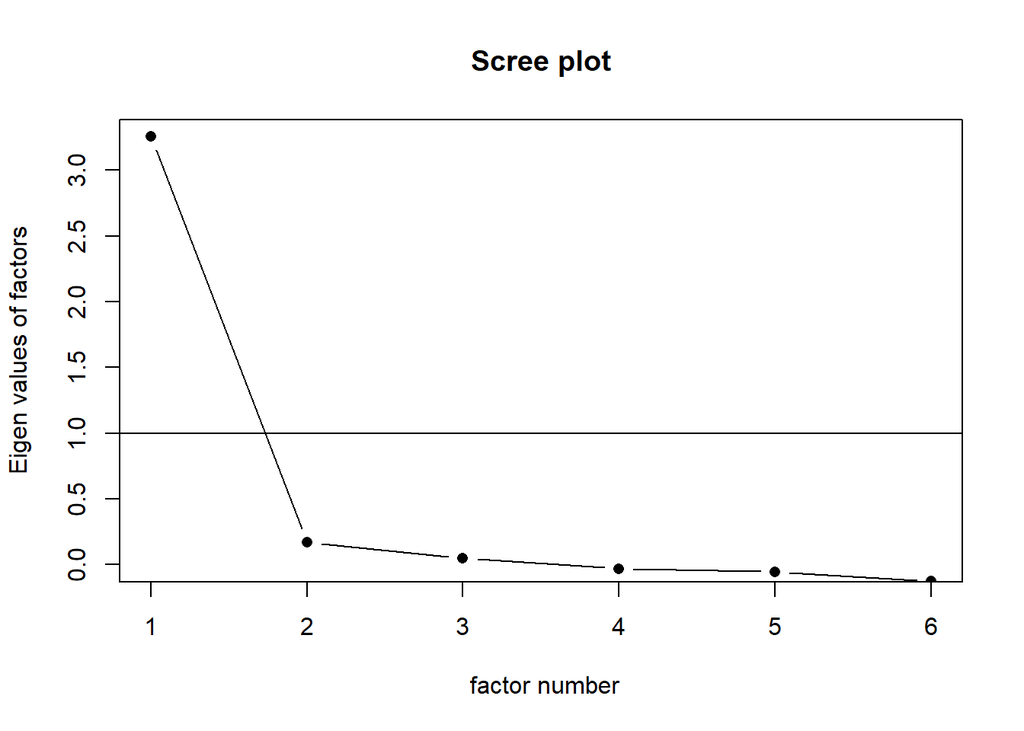

```r
sexism <- sexism %>%
  mutate(across(where(~ is.character(.)), ~ as.numeric(.)))

scree(sexism, pc = FALSE )
```

```r
data_r$sexism_mean <-rowMeans(data_r[c("SX_01", "SX_02","SX_03","SX_04","SX_05","SX_06")], na.rm = TRUE)
```

### GGS in diffrent areas

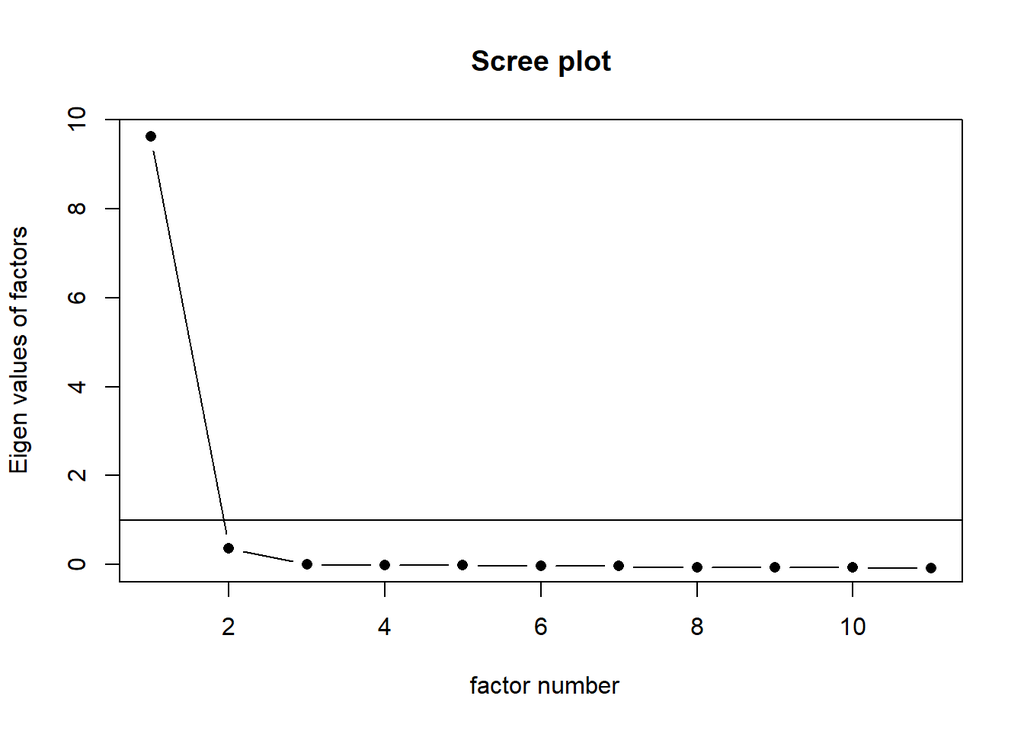

```r
GGS_areas <- GGS_areas %>%
  mutate(across(where(~ is.character(.)), ~ as.numeric(.)))
scree(GGS_areas,pc = FALSE )
```

```r
data_r$GGS_areas_mean <-rowMeans(data_r[c("AG03_01", "AG03_02", "AG03_03","AG03_04","AG03_05","AG03_06","AG03_07","AG03_08","AG03_09","AG03_10","AG03_11")], na.rm = TRUE)
```

### trans hostility

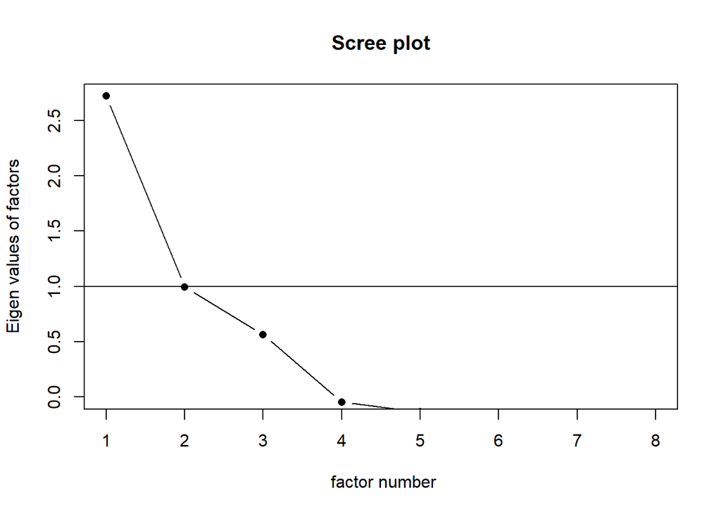

```r
transmisia <- transmisia %>%
  mutate(across(where(~ is.character(.)), ~ as.numeric(.)))
scree(transmisia, pc = FALSE )
```

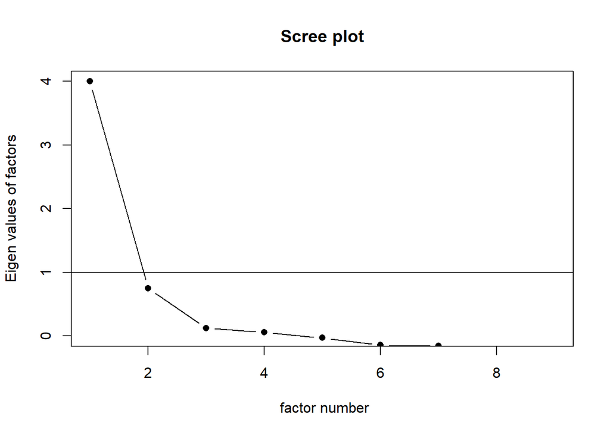

```r
data_r$transmisia_mean <-rowMeans(data_r[c("TX_01", "TX_02","TX_03","TX_04","TX_05","TX_06","TX_07","TX_08")], na.rm = TRUE)

scree(dn, pc = FALSE )
```

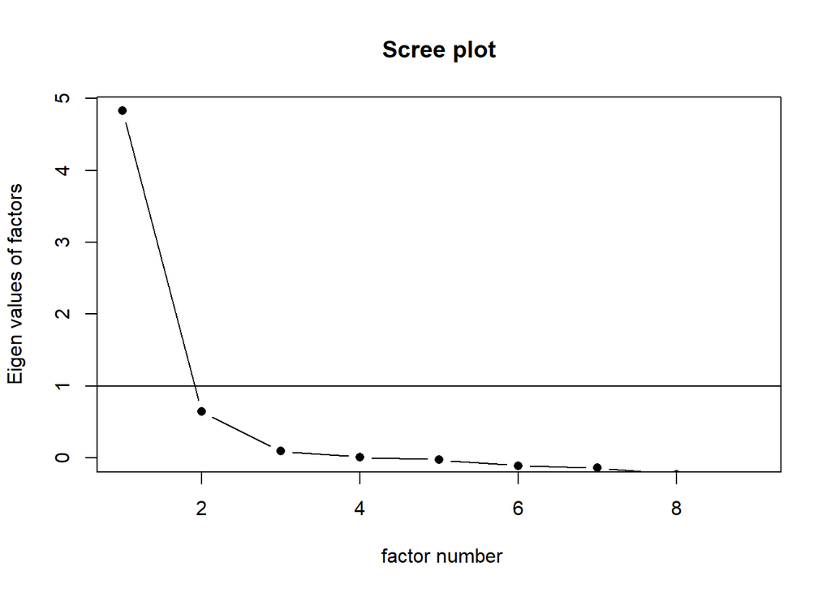

```r
scree(pn, pc = FALSE )
```

```r
cor_r <- data_r %>% select(transmisia_mean, sexism_mean, GGS_areas_mean, SN01_01, SN01_02, SN01_03,SN01_04,SN01_05,SN01_06,SN01_07,SN01_08,SN01_09, SN02_01, SN02_02,SN02_03,SN02_04,SN02_05,SN02_06,SN02_07,SN02_08,SN02_09)

cortable <- corx(cor_r, stars = c(.05, .01, .001), round = 2,describe =TRUE, grey_nonsig = TRUE)
corkable <-kable(align= 'ccccc',cortable$apa, caption = "Korrelationstabelle")
kable_paper(corkable, lightable_options =  c("striped", "hover"), html_font = "arial", fixed_thead = T)
```

Korrelationstabelle

transmisia_mean

sexism_mean

GGS_areas_mean

SN01_01

SN01_02

SN01_03

SN01_04

SN01_05

SN01_06

SN01_07

SN01_08

SN01_09

SN02_01

SN02_02

SN02_03

SN02_04

SN02_05

SN02_06

SN02_07

SN02_08

SN02_09

M

SD

transmisia_mean

.70***

-.33***

-.26***

-.06*

-.01

-.07*

-.04

-.09***

-.09**

-.13***

-.21***

-.26***

-.09***

-.05

-.08**

-.05

-.09**

-.09***

-.15***

-.20***

2.93

0.85

sexism_mean

.70***

-.27***

-.19***

.02

.03

-.01

-.02

-.03

-.03

-.08**

-.12***

-.20***

-.05

-.02

-.05

-.04

-.04

-.05

-.10***

-.13***

1.74

1.19

GGS_areas_mean

-.33***

-.27***

.66***

.22***

.17***

.29***

.19***

.35***

.35***

.43***

.50***

.69***

.38***

.33***

.43***

.35***

.44***

.45***

.53***

.57***

3.30

1.49

SN01_01

-.26***

-.19***

.66***

.39***

.19***

.34***

.18***

.39***

.39***

.54***

.57***

.80***

.49***

.31***

.40***

.30***

.44***

.42***

.56***

.59***

35.72

30.43

SN01_02

-.06*

.02

.22***

.39***

.33***

.47***

.30***

.36***

.39***

.51***

.36***

.34***

.57***

.37***

.42***

.33***

.36***

.38***

.44***

.33***

29.72

19.86

SN01_03

-.01

.03

.17***

.19***

.33***

.58***

.75***

.51***

.50***

.33***

.27***

.16***

.25***

.64***

.54***

.61***

.46***

.47***

.31***

.27***

65.15

30.07

SN01_04

-.07*

-.01

.29***

.34***

.47***

.58***

.61***

.55***

.73***

.48***

.38***

.30***

.39***

.58***

.71***

.59***

.53***

.66***

.47***

.36***

49.28

28.49

SN01_05

-.04

-.02

.19***

.18***

.30***

.75***

.61***

.47***

.52***

.33***

.27***

.18***

.27***

.65***

.54***

.70***

.43***

.50***

.34***

.26***

70.42

30.45

SN01_06

-.09***

-.03

.35***

.39***

.36***

.51***

.55***

.47***

.50***

.46***

.41***

.35***

.34***

.52***

.53***

.48***

.73***

.49***

.44***

.38***

47.62

33.94

SN01_07

-.09**

-.03

.35***

.39***

.39***

.50***

.73***

.52***

.50***

.45***

.43***

.36***

.36***

.54***

.65***

.54***

.48***

.76***

.45***

.43***

46.13

31.67

SN01_08

-.13***

-.08**

.43***

.54***

.51***

.33***

.48***

.33***

.46***

.45***

.48***

.53***

.47***

.41***

.47***

.39***

.48***

.44***

.72***

.47***

39.61

27.35

SN01_09

-.21***

-.12***

.50***

.57***

.36***

.27***

.38***

.27***

.41***

.43***

.48***

.54***

.38***

.33***

.41***

.31***

.43***

.44***

.48***

.80***

42.20

31.75

SN02_01

-.26***

-.20***

.69***

.80***

.34***

.16***

.30***

.18***

.35***

.36***

.53***

.54***

.52***

.37***

.45***

.37***

.46***

.46***

.61***

.63***

39.04

33.05

SN02_02

-.09***

-.05

.38***

.49***

.57***

.25***

.39***

.27***

.34***

.36***

.47***

.38***

.52***

.49***

.54***

.45***

.49***

.50***

.62***

.49***

32.58

22.11

SN02_03

-.05

-.02

.33***

.31***

.37***

.64***

.58***

.65***

.52***

.54***

.41***

.33***

.37***

.49***

.78***

.87***

.63***

.65***

.53***

.43***

58.74

30.63

SN02_04

-.08**

-.05

.43***

.40***

.42***

.54***

.71***

.54***

.53***

.65***

.47***

.41***

.45***

.54***

.78***

.79***

.69***

.79***

.61***

.51***

51.09

29.29

SN02_05

-.05

-.04

.35***

.30***

.33***

.61***

.59***

.70***

.48***

.54***

.39***

.31***

.37***

.45***

.87***

.79***

.62***

.68***

.52***

.42***

63.26

32.06

SN02_06

-.09**

-.04

.44***

.44***

.36***

.46***

.53***

.43***

.73***

.48***

.48***

.43***

.46***

.49***

.63***

.69***

.62***

.64***

.57***

.51***

45.86

34.41

SN02_07

-.09***

-.05

.45***

.42***

.38***

.47***

.66***

.50***

.49***

.76***

.44***

.44***

.46***

.50***

.65***

.79***

.68***

.64***

.59***

.53***

46.39

33.07

SN02_08

-.15***

-.10***

.53***

.56***

.44***

.31***

.47***

.34***

.44***

.45***

.72***

.48***

.61***

.62***

.53***

.61***

.52***

.57***

.59***

.60***

42.05

29.79

SN02_09

-.20***

-.13***

.57***

.59***

.33***

.27***

.36***

.26***

.38***

.43***

.47***

.80***

.63***

.49***

.43***

.51***

.42***

.51***

.53***

.60***

42.25

32.83